# Your Digest for Monday, Apr 15, 2024 11:59 PM

# Other physiological changes in pregnancy

- **Increased** tidal volume (not decreased by pressure on the diaphgram as you would imagine).
  - *Decreased pulmonary vascular resistance* (and ⬇ systemic vascular resistance)
  - ⬆ GFR
- *Free T4 is a better measure than total T4 in pregnancy* due to the increase in thyroid binding globulin.

[output not shown]

> ⭐*CYSTOISOSPORA* oocysts are larger than Cyclospora and Cryptosporidium oocysts, are ellipsoidal, and may contain one or two sporoblasts. Multiple (≥ 3) stool specimens may be needed because cyst secretion may be intermittent. [Source](https://www.msdmanuals.com/professional/infectious-diseases/intestinal-protozoa-and-microsporidia/cystoisosporiasis)

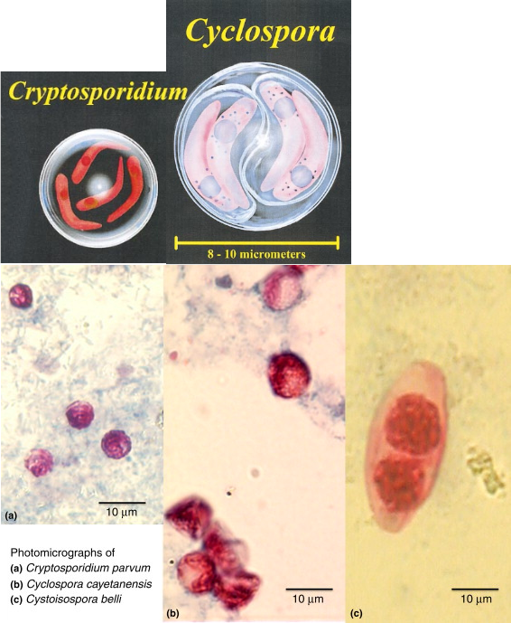

4. They infest the epithelial cells of the intestine (**intracellular parasites**). They produce **thick** (infective) and **thin** cysts (autoinfection).  
1. ⭐**Oocysts are resistant to chlorine levels found in pools**.  
5. **Diagnosis** - oocysts in stool but *routine stool examination isn't sensitive enough*. ⭐**Acid fast stains** and concentration techniques are required to increase sensitivity.  
1. Mnemonic: Crypto - hidden -> hard to find -> **need acid fast stain.**

⭐

[figure not shown]

- Cyclospora: Protozoan
- **Obligate human** parasite (Humans are only known host)
- Ingestion of *sporulated oocyst* from fruits / vegetables / water -> infection -> *infection of GI **mucosa***
- *Low grade fever* with anorexia, nausea, flatus, *diarrhoea* (symptoms can be semi-chronic, lasting several weeks to a month )
- Non-immunosuppressed patients are at equal risk.
- Incubation period = 7 days.
- "symptomatic infections typically manifest as **watery diarrhea of varying severity**. Other manifestations include complications of dysentery, crampy adbominal paint, further abdominal symptoms, and sometimes non-specific systemic symptoms"
- **Direct faeco oral transmission is not possible** as defecated unsporulated oocyst must mature for days / weeks in the environment.
- Treatment: ⭐**trimethoprim sulfamethoxazole.**
> - At *the milder end* of the spectrum, *mucosal leishmaniasis* (ML) and *leishmaniasis recidivans* (LR) are caused by oligoparasitic disease associated with a marked cellular immune response.
> - **The center** of the spectrum consists of **localized cutaneous leishmaniasis (LCL), which is the most common clinical presentation**.
> - At the opposite end of the spectrum, *diffuse cutaneous leishmaniasis* (DCL) is caused by polyparasitic disease with a predominance of parasitized macrophages and **no granulomatous inflammation**.
- Many species; each one having somewhat different clinical picture.
- Cutaneous leishmaniasis the commonest form in Sri Lanka. [Source](https://www.ncbi.nlm.nih.gov/pmc/articles/PMC7223001/)
- lesions are **NOT painful**.
- Regional #lymphadenopathy may be present.
- *Satellite* nodules can be present.

> It begins as a localized lesion **that does not ulcerate**; rather, amastigotes disseminate to macrophages in other areas of the skin. People who develop DCL usually have a *defect in **cell mediated** immunity*.
- So the causative parasites are L *brazilliensis*, *guyanensis*, *panamensis*, *amazonensis*)
- "black fever" refers to the *grayish skin colouration* that develop probably due to cytokine dysregulation.
- Incubation period = *2 months*;
- Symptom onset is insidious and patient *may feel well* despite abnormal clinical findings.
- #hepatosplenomegaly with #lymphadenopathy (but **lymphadenopathy isn't common**)
- Commonest presentation is with ⭐**abrupt onset fever with chills and rigors** which then **continues for weeks**.
- #Splenomegaly seen by the second week followed by #hepatomegaly.
- **Pancytopaenia** can lead to *thrombocytopenia* which causes epistaxis, petechiae, purpura or other bleeding.
- Untreated, the disease will progress to cause *pancytopaenia* and *immunosuppresion* leading to **⭐death in a year by superadded bacterial infection**.
- **Complications**: **DIC** or macrophage activation syndrome.
- **Diagnosis:** Identification of the organisms in **aspirate** of *bone marrow* or *liver or spleen*.
  - sensitivities: **spleen (90%)** -> Bone marrow -> lymph nodes.
  - Also *montenigro* test (similar to mantoux test for TB) - but this test is negative in the active phase of the disease. It also *remains positive for life* so in endemic areas, 70% are positive.

> Post-kala-azar dermal leishmaniasis (PKDL) is **a complication of visceral leishmaniasis (VL**); it is characterised by a macular, maculopapular, and **nodular rash** in a patient who has recovered from VL and who is *otherwise well*.
- Median time to onset is about **6 months to 2 years** **after treatment**.
- Associated with *Leishmania **donovani***.
> - **Ticks** *are not* involved in *typhus*.

?Usually, in MODY FBS is **moderately elevated**: 99 - 144;

> [!INFO] Treatment of MODY  
> **Mnemonic:** mutations with 'a' don't need insulin, mutations with 'b' definitely need insulin.

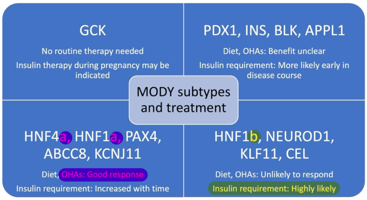

- *acceleration of terminal repolarization* (causes T wave abnormalities)
- Depression of *conduction between adjacent myocytes* -> Prolongation of PR and QRS duration. [Source](https://emj.bmj.com/content/19/1/74)  
  | Level | Changes | Basis |  
  | --------- | --------------------------------------------------------- | -------------------------------- |  
  | 5.5 - 6.5 | Tall t waves | **Repolarization abnormalities** |  
  | 6.5 - 7 | P wave widening and flattening, broadening of PR interval | **Progressive atrial paralysis** |  
  | 7.0 - 9.0 | Sinus brady, AV block, AF, conduction blocks | Conduction abnormalities |  
  | > 9.0 | Sine wave | Peri arrest |  
  In hyperkalemia, ECG changes progress from peaked T-waves to **widened QRS and** eventually to *ventricular tachycardia, fibrillation* or pulseless electrical activity arrest. These progressive changes can correlate with rising potassium levels.

# Effect of pregnancy on pharmacokinetics

#pregnancy  
[Source](https://derangedphysiology.com/main/cicm-primary-exam/required-reading/variability-drug-response/Chapter%20241/changes-drug-response-during-pregnancy)

- Maternal plasma **albumin is reduced** -> **lower protein binding of drugs**.
- Increased renal elimination due to increased GFR but renal reabosorption may increase for some drugs.
- Slow gastric emptying and *increased* gastric pH **reduce** absorption.
- Slower intestinal transit time **increases** absorption.
  - Net effect: for most drugs absorption is unchanged.
- *Lipophillic drugs* cross the placenta readily.
- The placenta *prevents* passage of drugs like **enoxaparin**
  - *Progesterone* induces liver enzymes.
  - Hepatobiliary clearance is reduced due to the cholestatic effects of *oestrogen*.  
    see [[Hypertension in pregnancy#Other physiological changes in pregnancy]]

> There are chemical and non chemical stimuli for regulation of respiration.  
> The sensors in the system are *central and peripheral chemoreceptors*. *They are sensitive to different parameters*.  
> Since wider inspired PO2s can be tolerated by the body, the **main regulators of respiratory drive in most states are PCO2 and pH**.  
> ⭐

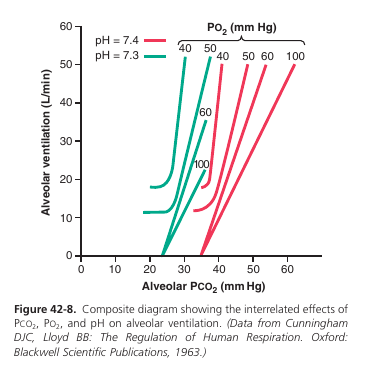

- Overall, PCO2 exerts the most influence on respiratory control.  
  PO2 based resiratory drive overrides the above two factors when PO2 drops to 'dangerously' low levels (i.e PaO2 approx 60.)
- Even Lower PO2 levels will directly *inhibit* the respiratory center.

> **Above Pao2 of 80 mm Hg, O2 has little effect on respiratory drive**

⭐

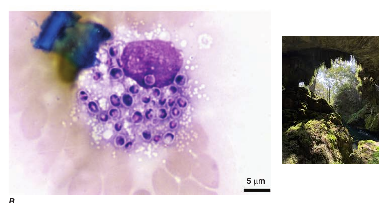